# Homework 7

Anna Schmoker

2/28/2018

# Creating a fake data set

Aim: detect quantify differences in the phosphorylation state of DCBLD2 tyrosines in YXXP motifs with various tyrosine (Y) to phenylalanine (F) mutants.

Background: DCBLD2 possesses seven YXXP motifs, which are each to a variable degree substrates of the tyrosine kinases Fyn and Abl. Phosphorylation of tyrosine residues in YXXP motifs are required for additional proteins to bind to DCBLD2. This study aims to determine whether phosphorylation of certain sites are required prior to the phosphorylation of additional sites. For example, this could be case if a certain kinase at the membrane phosphorylated a specific site (or sites), which was required for a cytoplasmic kinase to bind. The cytoplasmic kinase could phosphorylate different YXXP sites that then induced the binding of an effector molecule.

Hypothesis: Phosphorylation of certain YXXP sites are required for the phosphorylation of other YXXP sites.

Method: Express DCBLD2-Y750F (Y-to-F mutation of a single YXXP tyrosine) in HEK 293 cells in kinase activated conditions, immunoprecipitate DCBLD2 and separate IP’ed proteins via SDS-PAGE, prepare DCBLD2 band for LC-MS/MS to detect peptides encompassing YXXP tyrosine residues.

–> let’s start by looking at the non-YXXP, but highly phosphorylated, tyrosine Y715 in Abl activated conditions.

```r
library(ggplot2)
nGroup <- 3
nName <- c("NT DCBLD2 WT", "NT DCBLD2-Y750F", "Abl DCBLD2 WT", "Abl DCBLD2-Y750F")
nSize <- c(3,3,3,3)
nMean <- c(0,0,1.1,0.82)
nSD <- c(0.05,0.05,0.30,0.30)
ID <- 1:(sum(nSize))

resVar <- c(rnorm(n=nSize[1],mean=nMean[1],sd=nSD[1]),
            rnorm(n=nSize[2],mean=nMean[2],sd=nSD[2]),
            rnorm(n=nSize[3],mean=nMean[3],sd=nSD[3]),
            rnorm(n=nSize[4],mean=nMean[4],sd=nSD[4]))


TGroup <- rep(nName,nSize)

ANOdata <- data.frame(ID,TGroup,resVar)

str(ANOdata)
```

```
## 'data.frame':    12 obs. of  3 variables:
##  $ ID    : int  1 2 3 4 5 6 7 8 9 10 ...
##  $ TGroup: Factor w/ 4 levels "Abl DCBLD2 WT",..: 3 3 3 4 4 4 1 1 1 2 ...
##  $ resVar: num  -0.03262 -0.04022 -0.00839 0.031 -0.03959 ...
```

```r
head(ANOdata) # looks good
```

```
##   ID          TGroup       resVar
## 1  1    NT DCBLD2 WT -0.032615843
## 2  2    NT DCBLD2 WT -0.040219341
## 3  3    NT DCBLD2 WT -0.008385566
## 4  4 NT DCBLD2-Y750F  0.030999659
## 5  5 NT DCBLD2-Y750F -0.039588457
## 6  6 NT DCBLD2-Y750F  0.022647983
```

```r
ANOmodel <- aov(resVar~TGroup,data=ANOdata)
print(ANOmodel)
```

```
## Call:
##    aov(formula = resVar ~ TGroup, data = ANOdata)
##
## Terms:
##                   TGroup Residuals
## Sum of Squares  2.012304  1.112991
## Deg. of Freedom        3         8
##
## Residual standard error: 0.3729931
## Estimated effects may be unbalanced
```

```r
summary(ANOmodel) # significant p-value
```

```
##             Df Sum Sq Mean Sq F value Pr(>F)
## TGroup       3  2.012  0.6708   4.821 0.0334 *
## Residuals    8  1.113  0.1391
## ---
## Signif. codes:  0 '***' 0.001 '**' 0.01 '*' 0.05 '.' 0.1 ' ' 1
```

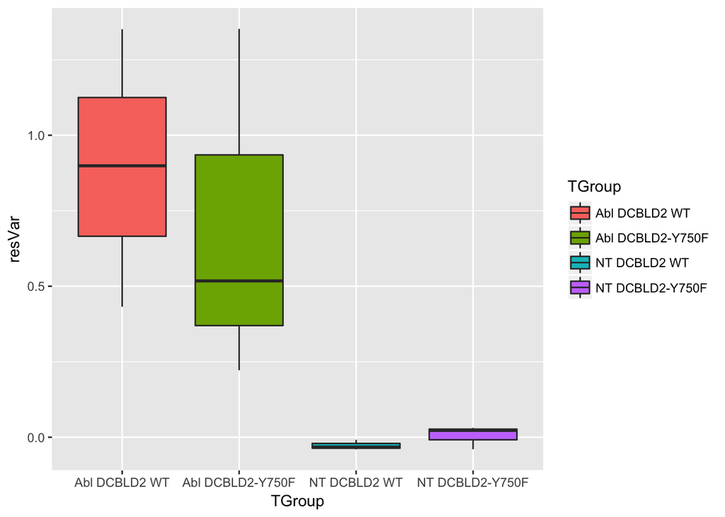

```r
ANOPlot <- ggplot(data=ANOdata,
                  aes(x=TGroup,y=resVar,fill=TGroup)) +
                  geom_boxplot()

print(ANOPlot)
```

Try in the form of a function…

```r
dataCreate <- function(m1=0,m2=0,m3=1.1,m4=0.82,n1=3,n2=3,n3=3,n4=3,sd1=0.05,sd2=0.05,sd3=0.30,sd4=0.30){
  dataFr <- data.frame(Control1=rnorm(mean=m1,n=n1,sd=sd1),
                       Control2=rnorm(mean=m2,n=n2,sd=sd2),
                       Treat1=rnorm(mean=m3,n=n3,sd=sd3),
                       Treat2=rnorm(mean=m4,n=n4,sd=sd4))
  return(dataFr)
}

dataSave <- dataCreate()
head(dataSave)
```

```
##      Control1    Control2    Treat1    Treat2
## 1 -0.06605718 -0.02387193 1.3629356 1.1360055
## 2 -0.02036617  0.03802189 0.6971928 0.4724039
## 3 -0.01773687  0.07749235 1.1353861 0.9741242
```

```r
library(reshape2)
melt(dataSave)
```

```
##    variable       value
## 1  Control1 -0.06605718
## 2  Control1 -0.02036617
## 3  Control1 -0.01773687
## 4  Control2 -0.02387193
## 5  Control2  0.03802189
## 6  Control2  0.07749235
## 7    Treat1  1.36293563
## 8    Treat1  0.69719282
## 9    Treat1  1.13538607
## 10   Treat2  1.13600546
## 11   Treat2  0.47240391
## 12   Treat2  0.97412419
```

```r
dataNew <- melt(dataSave)
ANOmodel2 <- aov(value~variable,data=dataNew)
summary(ANOmodel2) #  p-value fluctuates a lot...probably the small sample size
```

```
##             Df Sum Sq Mean Sq F value  Pr(>F)
## variable     3 2.8632  0.9544   16.07 0.00095 ***
## Residuals    8 0.4751  0.0594
## ---
## Signif. codes:  0 '***' 0.001 '**' 0.01 '*' 0.05 '.' 0.1 ' ' 1
```

```r
print(ANOmodel2)
```

```
## Call:
##    aov(formula = value ~ variable, data = dataNew)
##
## Terms:
##                  variable Residuals
## Sum of Squares  2.8632353 0.4751314
## Deg. of Freedom         3         8
##
## Residual standard error: 0.2437036
## Estimated effects may be unbalanced
```

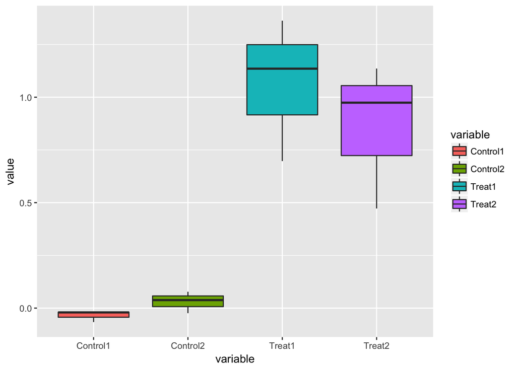

```r
ANOPlot2 <- ggplot(data=dataNew,aes(x=variable,y=value,fill=variable)) + geom_boxplot()

print(ANOPlot2)
```

Running the test multiple times, the results fluctuate quite a lot, most likely due to the small sample size.